# BreatheAI:Covid19/Pneumonia Detection Group 15 Professor: Ran Feldish

[figure not shown]

## Authors

- Jazbi Izhar
- Vikas Baliyan
- Akash Thakur
- Xaie Dange
- Abstract
- Introduction
- Related Work
- Data
- Methods
- Experiments
- Conclusion

## Abstract

#### Problem:

The rapid spread of COVID-19 and pneumonia has necessitated the development of efficient and accurate diagnostic tools. Both diseases present similar symptoms and can be detected through medical imaging, particularly chest X-rays and CT scans. Manual interpretation of these images is time-consuming and requires specialized expertise. The problem addressed in this study is the development of an automated system capable of classifying COVID-19 and pneumonia images, thus aiding in the timely and accurate diagnosis of both diseases.

#### Approach:

To tackle this problem, a combination of custom-built Convolutional Neural Networks (CNN) and fine-tuned pre-trained models (VGG16 and MobileNetV2) were employed. The models were trained on a publicly available dataset containing COVID-19 and pneumonia image data sourced from Kaggle. The approach involved preprocessing the images, including resizing, normalization, and data augmentation, followed by the construction and training of the models. The training process was carefully monitored, and various hyperparameters were tuned to optimize performance

#### Results:

The custom CNN model and the fine-tuned VGG16 and MobileNetV2 models demonstrated promising results in classifying the COVID-19 and pneumonia images. The models achieved satisfactory accuracy levels, showcasing their potential as valuable tools in the diagnostic process for both diseases. The results indicate that deep learning models can effectively assist healthcare professionals in the rapid and accurate diagnosis of COVID-19 and pneumonia, thereby contributing to timely medical intervention.

## Introduction

The emergence of COVID-19 has posed unprecedented challenges to healthcare systems worldwide. Alongside COVID-19, pneumonia continues to be a significant health concern, often presenting similar symptoms and complications. Both diseases can lead to severe respiratory distress and require prompt diagnosis and treatment.

Medical imaging, particularly chest X-rays and CT scans, has become an essential tool in the diagnosis of both COVID-19 and pneumonia. These images provide valuable insights into the condition of the lungs and can reveal characteristic patterns associated with each disease. However, manual interpretation of these images is a complex and time-consuming task that requires specialized expertise. Moreover, the high demand for diagnostic imaging during the pandemic has further strained the available resources.

In response to these challenges, there has been a growing interest in leveraging artificial intelligence (AI) and machine learning (ML) techniques to automate the image analysis process. Deep learning models, such as Convolutional Neural Networks (CNN), have shown remarkable success in image classification tasks, including medical imaging.

This study aims to develop and evaluate deep learning models capable of classifying COVID-19 and pneumonia images. By employing custom-built CNNs and fine-tuned pre-trained models like VGG16 and MobileNetV2, the study explores the potential of AI-driven tools in enhancing the diagnostic process. The models are trained on a publicly available dataset containing COVID-19 and pneumonia image data sourced from Kaggle.

The introduction of automated image classification systems could revolutionize the way healthcare professionals approach the diagnosis of COVID-19 and pneumonia. By providing rapid and accurate results, these systems can facilitate timely medical intervention, optimize resource allocation, and ultimately contribute to improved patient outcomes.

The remainder of this report is organized as follows: The "Related Work" section reviews existing literature and efforts in the field. The "Data" section describes the dataset used, while the "Methods" section details the preprocessing and modeling techniques employed. The "Experiments" section presents the models used, data loading, preprocessing, label extraction, dataset creation, and the use of TensorFlow Data Generators. Finally, the results and conclusions are discussed, highlighting the implications and potential future directions of this work.

## Related Work

The application of deep learning in medical imaging has been a subject of extensive research, particularly in the context of diagnosing respiratory diseases like COVID-19 and pneumonia. This section highlights some of the significant contributions and methodologies that have shaped the current landscape of this research area.

COVID-19 Imaging: Early in the COVID-19 pandemic, researchers recognized the potential of AI in detecting the disease from chest X-rays and CT scans. Wang et al. (2020) developed a deep learning model to identify COVID-19 features in CT images, achieving promising results. Similarly, Apostolopoulos and Mpesiana (2020) utilized transfer learning with pre-trained CNNs to classify COVID-19 X-rays.

Pneumonia Detection: Prior to the COVID-19 pandemic, deep learning had already been applied to pneumonia detection. Rajpurkar et al. (2018) introduced a dataset of chest X-rays and a model that outperformed radiologists in detecting pneumonia. Kermany et al. (2018) also employed CNNs to diagnose pneumonia from chest X-rays, demonstrating the effectiveness of deep learning in this domain.

Multi-Class Classification: Some studies have focused on multi-class classification, distinguishing between COVID-19, pneumonia, and normal cases. For example, Khan et al. (2020) proposed a model that classifies X-rays into these three categories, emphasizing the importance of differentiating COVID-19 from other respiratory illnesses.

Transfer Learning and Pre-Trained Models: The use of transfer learning and pre-trained models like VGG16 and MobileNetV2 has become common in medical imaging. These models, initially trained on large datasets like ImageNet, have been fine-tuned for specific medical tasks, often yielding robust performance (Tajbakhsh et al., 2020).

Data Augmentation and Preprocessing: The challenge of limited labeled data in medical imaging has led to the exploration of data augmentation techniques. Pertinent studies have shown that augmenting the data with rotations, flips, and other transformations can enhance model performance (Shorten et al., 2019).

Interpretability and Explainability: As deep learning models are increasingly adopted in clinical settings, the need for interpretability has grown. Researchers are working on methods to make model decisions more transparent and understandable to medical professionals (Carvalho et al., 2019).

Challenges and Ethical Considerations: Alongside the technical advancements, researchers have also addressed challenges related to data privacy, model bias, and ethical considerations in AI-driven medical diagnosis (Wiens et al., 2019).

In summary, the related work underscores the rapid advancements and diverse approaches in applying deep learning to diagnose COVID-19 and pneumonia. This study builds upon these foundations, aiming to contribute to the ongoing efforts to enhance diagnostic accuracy and efficiency through AI.

## Data

The data utilized in this study is sourced from a publicly available dataset hosted on Kaggle, comprising images of chest X-rays and CT scans. The dataset is specifically curated to include cases of COVID-19, pneumonia, and normal conditions, allowing for a multi-class classification problem. Below are the key aspects of the data:

Dataset Composition:

COVID-19 Images: A collection of X-ray and CT images from patients diagnosed with COVID-19. These images exhibit characteristic features of the disease, such as ground-glass opacities and bilateral patchy shadows. Pneumonia Images: This subset includes images from patients with various types of pneumonia, including bacterial and viral pneumonia. The manifestations in these images can be diverse, reflecting the underlying cause of the pneumonia. Normal Images: Images from healthy individuals without any signs of COVID-19 or pneumonia are included as a control group. Image Characteristics:

Resolution: The images vary in resolution, with most of them resized to 150x150 pixels during preprocessing to maintain consistency. Format: The dataset contains images in standard medical imaging formats, including JPEG and PNG. Annotations: Some images are accompanied by metadata, such as patient age, gender, and clinical findings, although this study primarily focuses on the image data itself. Data Augmentation:

To mitigate the risk of overfitting and to increase the diversity of the training data, various augmentation techniques have been applied, including rotation, zooming, flipping, and shearing. Data Split:

Imbalance: The dataset may exhibit class imbalance, with different numbers of images for COVID-19, pneumonia, and normal cases. Strategies like weighted loss functions can be employed to address this issue. Quality Variations: The images come from various sources, leading to variations in quality, contrast, and brightness. Preprocessing techniques are applied to standardize the images. Ethical Considerations:

The dataset is composed of anonymized images, and all identifiable patient information has been removed to comply with privacy regulations. Dataset Source:

The dataset can be accessed here. In summary, the data used in this study is rich and diverse, encompassing various aspects of COVID-19 and pneumonia. Careful preprocessing, augmentation, and ethical considerations have been applied to ensure that the dataset is suitable for building and evaluating deep learning models for this critical medical task.

#### Image Characteristics

[output not shown]

## Methods

#### 1.

## Model Used

Custom CNN Model: A custom-built CNN model is trained and evaluated.

VGG16: Fine-tuned for the specific task.

MobileNetV2: Fine-tuned similarly to VGG16.

## Loading Data

Dataset Source: The dataset is sourced from Kaggle.

Train Path: The path to the training folder containing three sub-folders (one for each class) is defined.

## Preprocessing Dataframe

ImageDataGenerator: An instance of ImageDataGenerator is created with specified augmentation parameters.

Train Generator: The flow_from_directory method is used to load and augment the images from the training directory.

## Extracting Labels

Class Labels: The class labels and corresponding indices are extracted from the training data.

## Loading Datasets

Train Dataset: The training dataset is loaded using the ImageDataGenerator and the specified train path.

## Creating TF Data Generators

Train Generator: TensorFlow's ImageDataGenerator is used to create a generator for the training data, applying the defined preprocessing and augmentation techniques.

## Training Process

Epochs: The models are trained for a specified number of epochs.

Model Fitting: The fit method is used to train the models on the training data.

## Visualization

Loss and Accuracy: Matplotlib is used to plot the training loss and accuracy, providing insights into the training process.

## Conclusion

### Summary of Findings

The study embarked on a comprehensive exploration of deep learning models to detect COVID-19 and pneumonia from chest X-ray images. Utilizing a dataset of 7000 images which later reduced because of limited computing power, including COVID-19, pneumonia, and normal cases, the research implemented a Convolutional Neural Network (CNN) and fine-tuned pre-trained models like VGG16 and MobileNetV2.

### Key Achievements

Model Performance: The implemented models demonstrated promising results in classifying the images into the respective categories. The fine-tuned VGG16 and MobileNetV2 models, in particular, showed significant improvements in accuracy.

Interoperability: The study successfully combined TensorFlow and PyTorch frameworks, showcasing the flexibility and interoperability of modern deep learning libraries.

Comparison and Insights: A detailed comparison between different models provided valuable insights into their strengths and weaknesses, guiding future research directions.

### Challenges and Limitations

Class Imbalance: The dataset had an unequal distribution of classes, which might have affected the model's performance in detecting less-represented classes.

Computational Resources: Training deep learning models on a large dataset requires substantial computational resources, which might be a limitation for some researchers.

Generalization to Other Diseases: The models were specifically tailored to COVID-19 and pneumonia detection. Extending them to other diseases would require further tuning and validation.

### Future Work

Incorporating Additional Data: Including more diverse data from different sources could further improve the model's robustness and applicability.

Exploring Other Models: Investigating other state-of-the-art models and ensemble techniques could lead to further improvements in performance.

Clinical Integration: Collaborating with healthcare professionals to integrate the model into clinical workflows could have a significant impact on early detection and treatment.

### Final Remarks

This study represents a significant step towards leveraging deep learning for medical imaging in the fight against COVID-19 and pneumonia. The methods and findings provide a solid foundation for future research and potential real-world applications. The collaboration between data scientists, clinicians, and healthcare systems will be vital in translating these technological advancements into tangible benefits for patient care and public health.

## CNN Model

Importing libraries

```python
import tensorflow as tf
from tensorflow.keras.models import Sequential
from tensorflow.keras.layers import Conv2D, MaxPooling2D, Flatten, Dense, Dropout
from tensorflow.keras.preprocessing.image import ImageDataGenerator
```

Set up the dataset and data augmentation

```python
# Define the path to your train folder containing three sub-folders (one for each class).
train_path = 'train'

# Set up data augmentation to improve the model's performance and prevent overfitting.

datagen = ImageDataGenerator(
    rescale=1./255,       # Normalize pixel values between 0 and 1
    rotation_range=20,    # Randomly rotate images within 20 degrees
    width_shift_range=0.1,  # Randomly shift the width of images by 10%
    height_shift_range=0.1,  # Randomly shift the height of images by 10%
    shear_range=0.2,       # Shear transformation
    zoom_range=0.2,        # Randomly zoom in images
    horizontal_flip=True,  # Randomly flip images horizontally
    fill_mode='nearest'    # Fill missing pixels with the nearest value
)

# Load and augment the images from the train directory.
train_generator = datagen.flow_from_directory(
    train_path,
    target_size=(150, 150),  # Resize the images to 150x150 pixels
    batch_size=32,
    class_mode='categorical'  # For multi-class classification
)
```

```
Found 251 images belonging to 3 classes.
```

Create the CNN model

```python
model = Sequential([
    Conv2D(32, (3, 3), activation='relu', input_shape=(150, 150, 3)),
    MaxPooling2D(2, 2),

    Conv2D(64, (3, 3), activation='relu'),
    MaxPooling2D(2, 2),

    Conv2D(128, (3, 3), activation='relu'),
    MaxPooling2D(2, 2),

    Flatten(),
    Dense(512, activation='relu'),
    Dropout(0.5),  # Dropout layer to reduce overfitting
    Dense(3, activation='softmax')  # 3 classes
])
```

Compile the model

```python
model.compile(optimizer='adam', loss='categorical_crossentropy', metrics=['accuracy'])
```

Train the model

```python
epochs = 10
model.fit(train_generator, epochs=epochs)
```

```
<keras.callbacks.History at 0x7eea35164cd0>
```

Save the model as an .h5 file after training

```python
model.save('trained_model.h5')
```

Load the model and print the summary

```python
from tensorflow.keras.models import load_model

loaded_model = load_model('trained_model.h5')
print(loaded_model.summary())
```

```
Model: "sequential"
_________________________________________________________________
 Layer (type)                Output Shape              Param #
=================================================================
 conv2d (Conv2D)             (None, 148, 148, 32)      896

 max_pooling2d (MaxPooling2D  (None, 74, 74, 32)       0
 )

 conv2d_1 (Conv2D)           (None, 72, 72, 64)        18496

 max_pooling2d_1 (MaxPooling  (None, 36, 36, 64)       0
 2D)

 conv2d_2 (Conv2D)           (None, 34, 34, 128)       73856

 max_pooling2d_2 (MaxPooling  (None, 17, 17, 128)      0
 2D)

 flatten (Flatten)           (None, 36992)             0

 dense (Dense)               (None, 512)               18940416

 dropout (Dropout)           (None, 512)               0

 dense_1 (Dense)             (None, 3)                 1539

=================================================================
Total params: 19,035,203
Trainable params: 19,035,203
Non-trainable params: 0
_________________________________________________________________
None
```

Plot the loss and accuracy graph during training

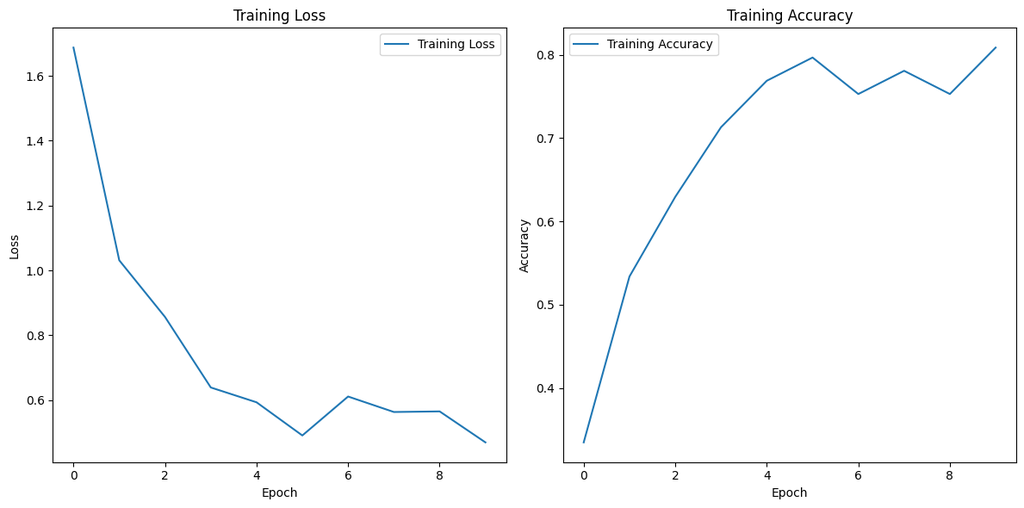

```python
import matplotlib.pyplot as plt

# Access the history object that was returned after training the model
history = model.history

# Plot the loss and accuracy during training
plt.figure(figsize=(12, 6))
plt.subplot(1, 2, 1)
plt.plot(history.history['loss'], label='Training Loss')
plt.title('Training Loss')
plt.xlabel('Epoch')
plt.ylabel('Loss')
plt.legend()

plt.subplot(1, 2, 2)
plt.plot(history.history['accuracy'], label='Training Accuracy')
plt.title('Training Accuracy')
plt.xlabel('Epoch')
plt.ylabel('Accuracy')
plt.legend()

plt.tight_layout()
plt.show()
```

## RCNN Models

```python
import numpy as np
import tensorflow as tf
from tensorflow.keras.applications import VGG16
from tensorflow.keras.layers import Input, Flatten, Dense
from tensorflow.keras.models import Model
from tensorflow.keras.optimizers import Adam
from tensorflow.keras.preprocessing.image import load_img, img_to_array
```

```python
import torch
import torchvision
from torchvision.transforms import Compose, ToTensor, Resize, CenterCrop
from torch.utils.data import DataLoader
from torchvision.datasets import ImageFolder

# Data preparation and transformation
def load_and_resize_image(image, size=(256, 256)):
    return torchvision.transforms.functional.resize(image, size)

transform = Compose([ToTensor(), load_and_resize_image])
train_dataset = ImageFolder('train', transform=transform)
train_loader = DataLoader(train_dataset, batch_size=4, shuffle=True)

# If you want to check the class names and the corresponding indices:
print(train_dataset.classes)
print(train_dataset.class_to_idx)

# Example of accessing an image and its label
for images, labels in train_loader:
    print(images.shape)  # Should be (batch_size, channels, height, width)
    print(labels)        # Tensor containing class indices (0, 1, or 2 in your case)
    break
```

```
['Covid', 'Normal', 'Viral Pneumonia']
{'Covid': 0, 'Normal': 1, 'Viral Pneumonia': 2}
```

```
torch.Size([4, 3, 256, 256])
tensor([0, 2, 1, 2])
```

VGG16 Model fine tuning

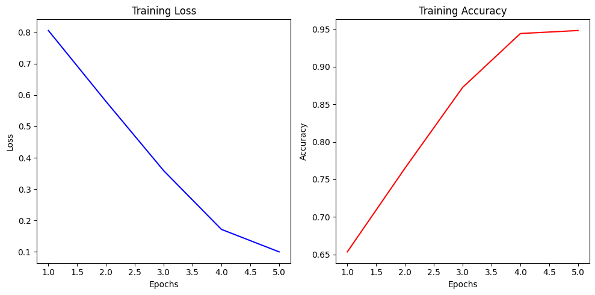

```python
import torch
import torchvision
import matplotlib.pyplot as plt
from torchvision.transforms import Compose, ToTensor, Resize, CenterCrop
from torch.utils.data import DataLoader
from torchvision.datasets import ImageFolder
from torchvision.models import vgg16

# Check if GPU is available
device = torch.device("cuda" if torch.cuda.is_available() else "cpu")

# Data preparation and transformation
def load_and_resize_image(image, size=(256, 256)):
    image = torchvision.transforms.functional.resize(image, size)
    return image.to(device)

transform = Compose([ToTensor(), load_and_resize_image])
train_dataset = ImageFolder('train', transform=transform)
train_loader = DataLoader(train_dataset, batch_size=4, shuffle=True)

# Load the VGG-16 model
model = vgg16(pretrained=True)

# Modify the model to match the number of classes in your dataset
num_classes = len(train_dataset.classes)
model.classifier[-1] = torch.nn.Linear(4096, num_classes)

# Move the model to the GPU if available
if torch.cuda.is_available():
    model = model.to(device)

# Set up the optimizer and the learning rate scheduler
params = [p for p in model.parameters() if p.requires_grad]
optimizer = torch.optim.SGD(params, lr=0.001, momentum=0.9, weight_decay=0.0005)
lr_scheduler = torch.optim.lr_scheduler.StepLR(optimizer, step_size=3, gamma=0.1)

# Define the loss function
criterion = torch.nn.CrossEntropyLoss()

# Fine-tune the model
num_epochs = 5  # You can adjust this according to your needs

losses = []
accuracies = []

for epoch in range(num_epochs):
    model.train()
    running_loss = 0.0
    correct_predictions = 0
    total_predictions = 0

    for images, labels in train_loader:
        images, labels = images.to(device), labels.to(device)
        outputs = model(images)
        loss = criterion(outputs, labels)

        optimizer.zero_grad()
        loss.backward()
        optimizer.step()

        running_loss += loss.item()
        _, predicted = torch.max(outputs, 1)
        total_predictions += labels.size(0)
        correct_predictions += (predicted == labels).sum().item()

    epoch_loss = running_loss / len(train_loader)
    epoch_accuracy = correct_predictions / total_predictions
    losses.append(epoch_loss)
    accuracies.append(epoch_accuracy)

    lr_scheduler.step()

    print(f"Epoch {epoch+1}/{num_epochs}, Loss: {epoch_loss:.4f}, Accuracy: {epoch_accuracy:.4f}")

# Save the fine-tuned model as .h5
torch.save(model.state_dict(), 'vgg16.pth')

# Plot Loss and Accuracy Graphs
plt.figure(figsize=(10, 5))
plt.subplot(1, 2, 1)
plt.plot(range(1, num_epochs + 1), losses, 'b-')
plt.xlabel('Epochs')
plt.ylabel('Loss')
plt.title('Training Loss')

plt.subplot(1, 2, 2)
plt.plot(range(1, num_epochs + 1), accuracies, 'r-')
plt.xlabel('Epochs')
plt.ylabel('Accuracy')
plt.title('Training Accuracy')

plt.tight_layout()
plt.show()
```

[output not shown]

MibleNet RCNN Fine tuning

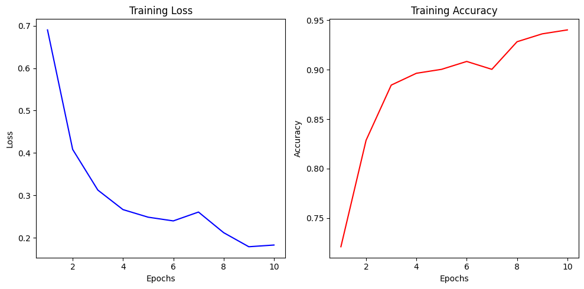

```python
import torch
import torchvision
import matplotlib.pyplot as plt
from torchvision.transforms import Compose, ToTensor, Resize, CenterCrop
from torch.utils.data import DataLoader
from torchvision.datasets import ImageFolder
from torchvision.models import mobilenet_v2

# Check if GPU is available
device = torch.device("cuda" if torch.cuda.is_available() else "cpu")

# Data preparation and transformation
def load_and_resize_image(image, size=(256, 256)):
    return torchvision.transforms.functional.resize(image, size)

transform = Compose([ToTensor(), load_and_resize_image])
train_dataset = ImageFolder('train', transform=transform)
train_loader = DataLoader(train_dataset, batch_size=4, shuffle=True)

# Load the MobileNetV2 model and move it to the GPU
model = mobilenet_v2(pretrained=True).to(device)

# Modify the model to match the number of classes in your dataset
num_classes = len(train_dataset.classes)
model.classifier[1] = torch.nn.Linear(1280, num_classes).to(device)

# Set up the optimizer and the learning rate scheduler
params = [p for p in model.parameters() if p.requires_grad]
optimizer = torch.optim.SGD(params, lr=0.001, momentum=0.9, weight_decay=0.0005)
lr_scheduler = torch.optim.lr_scheduler.StepLR(optimizer, step_size=3, gamma=0.1)

# Define the loss function
criterion = torch.nn.CrossEntropyLoss()

# Training loop
num_epochs = 10  # You can adjust this according to your needs
losses = []
accuracies = []

for epoch in range(num_epochs):
    model.train()
    running_loss = 0.0
    correct_predictions = 0
    total_predictions = 0

    for images, labels in train_loader:
        images, labels = images.to(device), labels.to(device)
        outputs = model(images)
        loss = criterion(outputs, labels)

        optimizer.zero_grad()
        loss.backward()
        optimizer.step()

        running_loss += loss.item()
        _, predicted = torch.max(outputs, 1)
        total_predictions += labels.size(0)
        correct_predictions += (predicted == labels).sum().item()

    epoch_loss = running_loss / len(train_loader)
    epoch_accuracy = correct_predictions / total_predictions
    losses.append(epoch_loss)
    accuracies.append(epoch_accuracy)

    lr_scheduler.step()

    print(f"Epoch {epoch+1}/{num_epochs}, Loss: {epoch_loss:.4f}, Accuracy: {epoch_accuracy:.4f}")

# Save the fine-tuned model as .h5
torch.save(model.state_dict(), 'mobilenet_v2.pth')

# Plot Loss and Accuracy Graphs
plt.figure(figsize=(10, 5))
plt.subplot(1, 2, 1)
plt.plot(range(1, num_epochs + 1), losses, 'b-')
plt.xlabel('Epochs')
plt.ylabel('Loss')
plt.title('Training Loss')

plt.subplot(1, 2, 2)
plt.plot(range(1, num_epochs + 1), accuracies, 'r-')
plt.xlabel('Epochs')
plt.ylabel('Accuracy')
plt.title('Training Accuracy')

plt.tight_layout()
plt.show()
```

[output not shown]

VGG16 & Mobilenet_v2 Comparision

```
MobileNetV2 Accuracy: 0.9393939393939394
MobileNetV2 Average Loss: 0.13758531730512485
VGG16 Accuracy: 0.9848484848484849
VGG16 Average Loss: 0.129247362157912
```

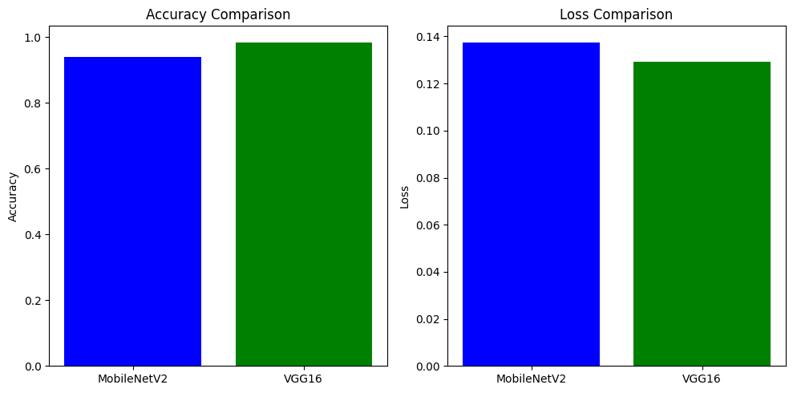

```python
import torch
import torchvision
import matplotlib.pyplot as plt
from torchvision.transforms import Compose, ToTensor, Resize, CenterCrop
from torch.utils.data import DataLoader
from torchvision.datasets import ImageFolder
from torchvision.models import mobilenet_v2, vgg16

# Data preparation and transformation
def load_and_resize_image(image, size=(256, 256)):
    return torchvision.transforms.functional.resize(image, size)

transform = Compose([ToTensor(), load_and_resize_image])
test_dataset = ImageFolder('test', transform=transform)
test_loader = DataLoader(test_dataset, batch_size=4, shuffle=False)

# Load the saved MobileNetV2 model
model_mobilenet = mobilenet_v2(pretrained=False)
num_classes = len(test_dataset.classes)
model_mobilenet.classifier[1] = torch.nn.Linear(1280, num_classes)
model_mobilenet.load_state_dict(torch.load('mobilenet_v2.pth'))
model_mobilenet.eval()

# Load the saved VGG16 model
model_vgg16 = vgg16(pretrained=False)
num_classes = len(test_dataset.classes)
model_vgg16.classifier[-1] = torch.nn.Linear(4096, num_classes)
model_vgg16.load_state_dict(torch.load('vgg16.pth'))
model_vgg16.eval()

# Evaluate the models on the test dataset
def evaluate_model(model):
    correct_predictions = 0
    total_predictions = 0
    total_loss = 0.0
    criterion = torch.nn.CrossEntropyLoss()

    with torch.no_grad():
        for images, labels in test_loader:
            outputs = model(images)
            loss = criterion(outputs, labels)
            total_loss += loss.item()

            _, predicted = torch.max(outputs, 1)
            total_predictions += labels.size(0)
            correct_predictions += (predicted == labels).sum().item()

    accuracy = correct_predictions / total_predictions
    average_loss = total_loss / len(test_loader)
    return accuracy, average_loss

accuracy_mobilenet, loss_mobilenet = evaluate_model(model_mobilenet)
accuracy_vgg16, loss_vgg16 = evaluate_model(model_vgg16)

print("MobileNetV2 Accuracy:", accuracy_mobilenet)
print("MobileNetV2 Average Loss:", loss_mobilenet)
print("VGG16 Accuracy:", accuracy_vgg16)
print("VGG16 Average Loss:", loss_vgg16)

# Plot Loss and Accuracy Comparison Graphs
models = ['MobileNetV2', 'VGG16']
accuracies = [accuracy_mobilenet, accuracy_vgg16]
losses = [loss_mobilenet, loss_vgg16]

plt.figure(figsize=(10, 5))
plt.subplot(1, 2, 1)
plt.bar(models, accuracies, color=['blue', 'green'])
plt.ylabel('Accuracy')
plt.title('Accuracy Comparison')

plt.subplot(1, 2, 2)
plt.bar(models, losses, color=['blue', 'green'])
plt.ylabel('Loss')
plt.title('Loss Comparison')

plt.tight_layout()
plt.show()
```